# Lab 4 Avocado Prices

Author

Adam Kong

# **Lab 4: Avocado Prices**

**Tip**

I advise you to focus particularly on:

- Setting chunk options carefully.
- Making sure you don’t print out more output than you need to.
- Making your code readable and nicely formatted.
- Thinking through your desired result before writing any code.

## Lab 4 Reflection

What I learned from this week was to try and make things more organised. While I said something similar last week, I realized I’m not very organized with my code. I feel like I need to find better and shorter codes that make it much better. A problem with my code is that I know things are functional, but they could be done much better which is something I want to improve on.

Another thing I learned is that Google is your best friend. I was trying to find a way to get the bars in the column to go the right way. I knew they weren’t going the right way because the column order was in the opposite way due to the factor variable order. For the legend I even got rid of the underscore between the avocado sizes.

One thing I think I could improve on is the exclusion or inclusion regions. I feel they could be done in one or two more steps. I also feel like I could be a much more efficient coder. On the right of my screen I notice so many data sets and I feel if time allotted, I could reduce the amount of data sets in my code.

# **1 Getting Started**

[Download `avocado.csv`](https://atheobold.github.io/stat-331/4_tidyr-joins/Lab/avocado.csv)

**Warning**

Save **both** your .qmd file and your data set in the same folder within your Stat 331 directory!

# **2 Introduction & Set-up**

In this lab we’re going to be looking at avocado prices.

The dataset comes to us from Kaggle and represents weekly retail scan data. A description of the data can be found [here.](https://www.kaggle.com/neuromusic/avocado-prices)

**Note**

The data set website is an updated data set from the original published in 2018. Please refer to the [main page](https://www.kaggle.com/datasets/neuromusic/avocado-prices) of the original data set for a description of the columns.

## Step 0

**0.** Create a Quarto file, load the data, and declare your package dependencies.

```r
library(tidyverse)
```

```r
avocado <- read_csv(here::here("Week 4", "Lab 4", "avocado.csv"))

# Rename avocado sizes

avocado <- avocado |>
  rename("Small" = `4046`, "Large" = `4225`, "ExtraLarge" = `4770`)
```

## Step 1

**1.** Briefly describe the dataset. What information does it contain?

The information in avocado.csv is the historical avocado prices and sales volumes in the United States market. **The data comes from retail sales of Hass Avocados ranging from the years 2015 to 2018.** Also contained in the data set is the observation date, average price, a type variable between conventional or organic grown avocados. The year, the region, the total volume of avocados, and the total number of avocados for each size. **The data was collected from retailer’s cash registers based on actual Hass Avocado sales.**

4046 - Small Hass Avocado

4225 - Large Hass Avocado

4770 - Extra Large Hass Avocado

## Step 2

**2.** Clean the data in any way you see fit.

```r
region_major <- tibble(region = c("GreatLakes",
                                  "Midsouth",
                                  "Northeast",
                                  "Plains",
                                  "SouthCentral",
                                  "Southeast",
                                  "West")
                       )

region_not_included <- region_major |>
  bind_rows(tibble(region = c("California",
                              "SouthCarolina",
                              "TotalUS")))

# Data sets below


region_avocado <- avocado |>
  semi_join(region_major, by = "region")

metro_avocado <- avocado |>
  anti_join(region_not_included)

# Top 5 Avocado Metro Region

topFiveRegions <- metro_avocado |>
  group_by(region) |>
  summarise(mean_sold = mean(`Total Volume`)) |>
  arrange(desc(mean_sold)) |>
  slice_max(mean_sold, n = 5)

graphFiveMetro <- avocado |>
  right_join(topFiveRegions)
```

## Step 3

Which major region sold the most organic, small Hass avocados in 2017?

```r
small_avocado_2017 <- region_avocado |>
  filter(year == 2017, type == "organic") |>
  group_by(region) |>
  summarise(small_sum_sold = sum(Small)) |>
  arrange(desc(small_sum_sold))

max_2017 <- small_avocado_2017 |>
  slice_max(small_sum_sold)

max_2017
```

```
# A tibble: 1 × 2
  region small_sum_sold
  <chr>           <dbl>
1 West         1870206.
```

The West Region sold the most organic Small Hass Avocados in 2017 with 1,870,206 avocados sold that year.

Step 4

**4.** Use the `separate()` function to split the `Date` variable into year, month, and day. In which month is the highest volume of avocado sales?

```r
region_avocado |>
  separate(Date, c("Year", "Month", "Day")) |>
  group_by(Month) |>
  summarise(sold_mean = mean(`Total Volume`)) |>
  arrange(desc(sold_mean)) |>
  slice_max(sold_mean)
```

```
# A tibble: 1 × 2
  Month sold_mean
  <chr>     <dbl>
1 02     2432533.
```

```r
# Looking at the individual sales, we can see that Feburary had the most amount of avocados sold.
```

February sold the most volume of avocados through all types of avocados and years.

## Step 5

**5.** Which metro area regions sold the most total avocados? Plot side-by-side boxplots of total volume for only the five regions with the highest averages for the `Total Volume` variable.

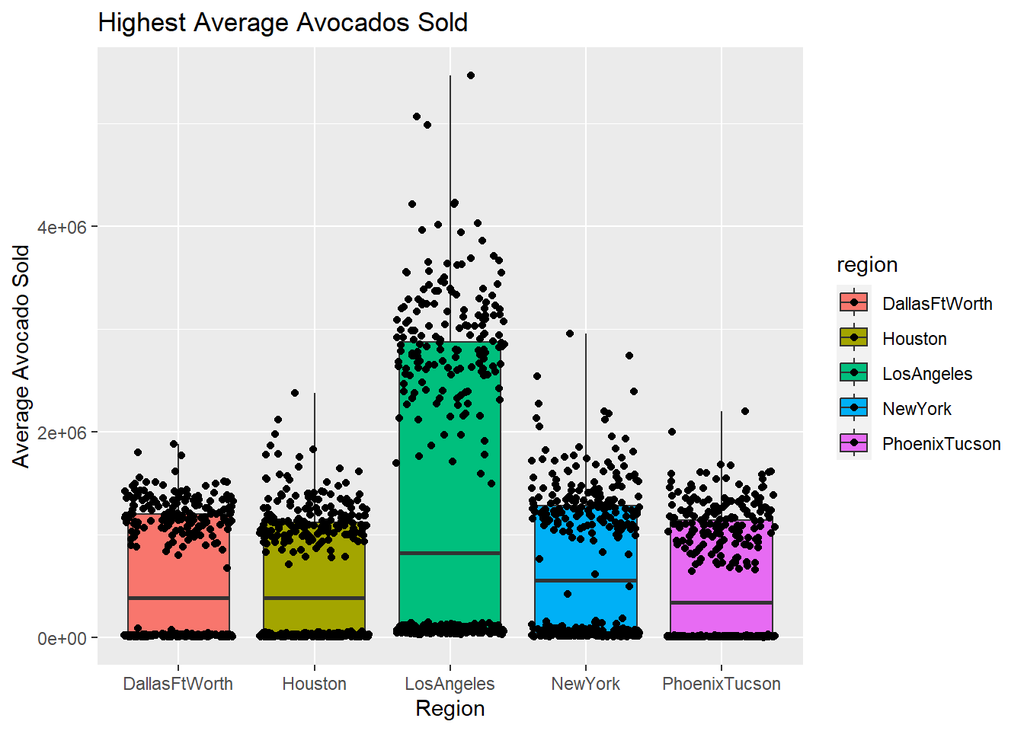

```r
# Top most sold avocados for the five metro regions were:
# Los Angeles, New York, Dallas Fortworth, Houston, Phoenix Tuscon

ggplot(graphFiveMetro, aes(x = region, y = `Total Volume`, fill = region)) +
  geom_boxplot() +
  geom_jitter() +
  labs(
    title = "Highest Average Avocados Sold",
    x = "Region",
    y = "Average Avocado Sold"
  )
```

## Step 6

The following four California regions are in this dataset: `"LosAngeles"`, `"SanDiego"`, `"Sacramento"`, and `"SanFrancisco"`. Answer the following questions about these California regions **only**.

**6.** In which regions is the price of organic versus conventional avocados most different? Support your answer with a few summary statistics and a visualization.

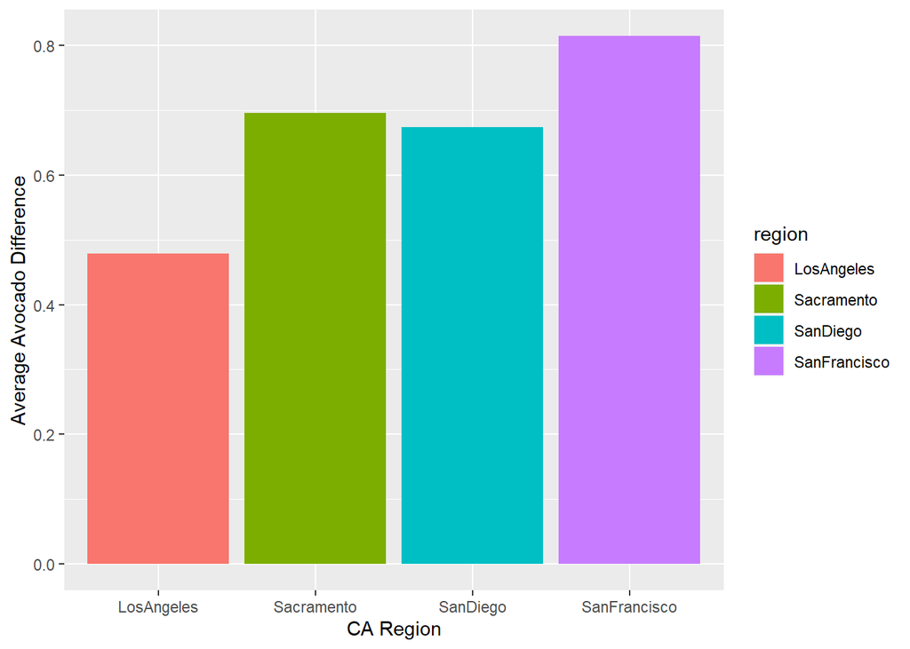

```r
california_cities <- tibble(region = c("LosAngeles",
                                       "SanDiego",
                                       "Sacramento",
                                       "SanFrancisco"))

cali_avocados <- avocado |>
  semi_join(california_cities, by = "region")

cali_organic_convention <- cali_avocados |>
  group_by(type, region) |>
  summarise(meanprice = mean(AveragePrice)) |>
  pivot_wider(names_from = type,
               values_from = meanprice) |>
  mutate(avocadoDiff = organic - conventional) |>
  select(region, avocadoDiff)

ggplot(cali_organic_convention, mapping = aes(x = region,
                                              y = avocadoDiff,
                                              fill = region)) +
  geom_col() +
  labs(x = "CA Region", y = "Average Avocado Difference")
```

## Step 7

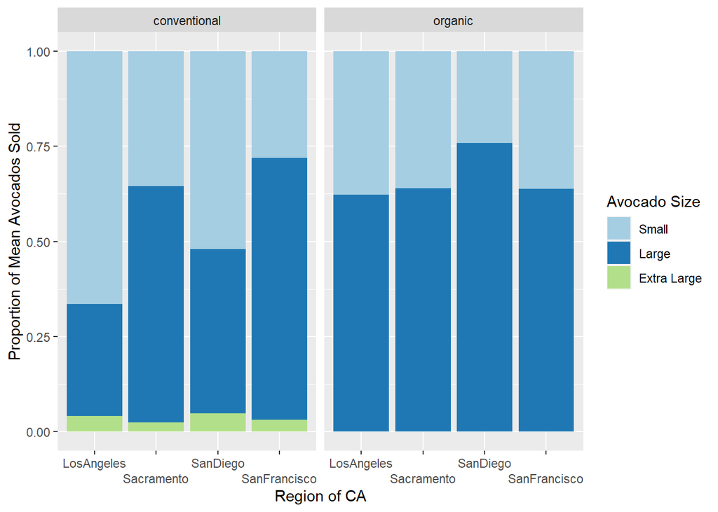

```r
recreate_graph <- cali_avocados |>
  select(Small, Large, ExtraLarge, type, region) |>
  pivot_longer(cols = Small:ExtraLarge,
               names_to = "Avocado Size",
               values_to = "Avocado_Sold") |>
  group_by(region, type, `Avocado Size`) |>
  summarise(mean_sold = mean(Avocado_Sold)) |>
  arrange(desc(`Avocado Size`)) |>
  mutate(`Avocado Size`= factor(`Avocado Size`, level = c('Small',
                                                          'Large',
                                                          'ExtraLarge')))

# https://www.guru99.com/r-factor-categorical-continuous.html#:~:text=What%20is%20Factor%20in%20R,integer%20data%20values%20as%20levels.

ggplot(recreate_graph, aes(fill = `Avocado Size`,
                           x = region,
                           y = mean_sold)) +
  geom_bar(position = "fill", stat = "identity") +
  facet_grid(~type) +
  labs(
    x = "Region of CA",
    y = "Proportion of Mean Avocados Sold",
  ) +
  scale_fill_manual(labels = c("Small", "Large", "Extra Large"), values = c("#a6cee3", "#1f78b4", "#b2df8a")) +
  scale_x_discrete(guide = guide_axis(n.dodge = 2))
```

```r
# https://ggplot2.tidyverse.org/articles/faq-axes.html
```

# **5 Challenge**

A joke in the media is that Millennials can’t afford houses, because they spend all their money buying avocado toast. Let’s use this dataset to address that claim.

> Find or make a dataset with house prices for these four California regions. Join this dataset with your California avocado dataset.

> Use your new joined dataset to make an argument about the relationship between house prices and avocado prices/sales.

> Support your argument with a plot.